# Act6: Comparing several samples

Dr. Islam

Winter, 2022

**Act 6, Ref: Chapter 5**

# Objectives

- Find out a pooled estimate of common variance and standard deviation for multiple samples
- Compare two means out of many means using a t test.
- Find residual sums of square of full and reduced model
- Find Extra sum of squares
- Apply F test to compare three or more treatment means using ANOVA approach.

# Pooled estimate of common variance

Given $K$ independent samples with sample means $\bar Y_i$ and sample variances $s_i^2$, $i=1,2,\cdots, K$ from K populations with means $\mu_i, i=1,2,\cdots, K$, and common variance $\sigma^2$, the pooled estimate of $\sigma^2$ is given by

$$s_p^2=\frac{(n_1-1)s_1^2+(n_2-1)s_2^2+\cdots+(n_K-1)s_K^2}{(n_1-1)+(n_2-1)+\cdots+(n_K-1)}$$
The number of degrees of freedom associated with $s_p^2$ is $(n_1-1)+(n_2-1)+\cdots+(n_K-1)=n-K$ where $n=\sum_{i=1}^K n_i.$

# Compare any two of $K$ means

Compare any two means of $K$ means from $K$ populations with a common variance via a two-sample t-test, For example, to compare $l$th and $m$th population means, $\mu_l$ and $\mu_m$, use the T-test statistic given
$$T=\frac{\bar Y_l-\bar Y_m}{s_p\sqrt{\frac{1}{n_l}+\frac{1}{n_m}}}\sim t_{n-K}$$
where $s_p^2$ is the pooled estimate of the common variance defined before.

# ANOVA and Full Model vs Reduced Model

In the analysis of variance (ANOVA), we test
$$H_0:\mu_1=\cdots=\mu_K$$
vs
$$H_1: At ~least~ one~ of ~the~ K~ means ~differs~ from ~the ~others$$

The full model or separate-means model is the unrestricted model. The null model is called the reduced model or equal-means model:

| Group: | 1 | 2 | 3 | 4 | $\cdots$ | K |
| --- | --- | --- | --- | --- | --- | --- |
| Full model | $\mu_1$ | $\mu_2$ | $\mu_3$ | $\mu_4$ | $\cdots$ | $\mu_K$ |
| Reduced model | $\mu$ | $\mu$ | $\mu$ | $\mu$ | $\cdots$ | $\mu$ |

where $\mu$ is the common mean of all treatments in the reduced model.

The estimated parameters in the full are reduced models are as follows:

| Group: | 1 | 2 | 3 | 4 | $\cdots$ | K |
| --- | --- | --- | --- | --- | --- | --- |
| Full model | $\bar Y_1$ | $\bar Y_2$ | $\bar Y_3$ | $\bar Y_4$ | $\cdots$ | $\bar Y_K$ |
| Reduced model | $\bar Y$ | $\bar Y$ | $\bar Y$ | $\bar Y$ | $\cdots$ | $\bar Y$ |

where $\bar Y$ is the mean of all observations in the $K$ treatments, called the grand mean.

- the residual sum of squares of the **full or separate-means model** is given by
  $$RSS_F=\sum_i\sum_j(Y_{ij}-\bar Y_i)^2,~ \text{with associated}~ df_F=n-K.$$
- the residual sum of squares of the **reduced or the equal-means model** is given by
  $$RSS_R=\sum_i\sum_j(Y_{ij}-\bar Y)^2, ~\text{with associated}~ df_R=n-1.$$
- $ExtraSS=RSS_R-RSS_F, ~\text{with associated}~ df_{Extra}=K-1.$

An $F$-test is defined as follows
$$F=\frac{ExtraSS/df_{Extra}}{RSS_F/df_{F}}\sim F_{K-1,n-K}$$
The critical value of the test is $F_{\alpha/2;K-1,n-K}$.

The p-value is given by
$$2\times \min \left \{Pr(F_{K-1,n-K}\le F^*), Pr(F_{K-1,n-K}\ge F^*)\right \}$$
,

where $F^*$ is the observed value of the test statistic $F$

**Notes**

$$\sum_i\sum_j(Y_{ij}-\bar Y)^2=\sum_i\sum_j(Y_{ij}-\bar Y_i)^2+\sum_i\sum_j(\bar Y_{i}-\bar Y)^2$$
$$TotalSS=ResidualSS+TreatmentSS$$
Thus,

- The $RSS_F$ is also called the **ResidualSS** or **WithinSS** (reported with ANOVA).
- The ExtraSS is also called the **SSTreatment** (reported with ANOVA).
- The $RSS_R$ is also called the **TotalSS**.

A series of studies involving several species of animals found that restricting calorie intake can dramatically increase life expectancy.

In **activity 6**, we explore lifetime of female mice due to restricting calorie intake. The data in case0501 refers to lifespan of female mice randomly assigned to one of the following six treatment groups

1. NP- Fed normally with non-purified standard diet until pleased.
2. N/N85- Fed normally before weaning and after weaning at a constant 85kcal/week.
3. N/R50- Fed normally before weaning and reduced diet at 50kcal/week after weaning.
4. R/R50- Fed reduced 50kcal/week before and after weaning.
5. N/R50 lopro- Fed normally before weaning and reduced diet at 50kcal/week after weaning and decreasing dietary protein with advancing age.
6. N/R40- Fed normally before weaning and reduced diet at 40kcal/week after weaning.

Using the data in case0501, perform the following computations:

1. Report the first 2 observations of the data, and favstats.
2. Extract n, mean, and sd from the favstats due to different diet (i.e., calorie intake).
3. Find and report the margin of error of 95% confidence interval for mean lifespan due to each diet.
4. Provide 95% CI estimates labelled as LCL and UCL for the mean lifespan due to different calorie intake.
5. Create a dataframe named **dfr** with columns n, mean, LCL and UCL, with values in one decimal points.
6. Assign diet types as rownames of the dataframe dfr, and print it.
7. Assume that the variance of lifespan due to all calorie intake is equal and unknown. Find the pooled estimate of the common variance ($s_p^2$) and standard deviation ($s_p$).
8. Test $H_0:\mu_{N/N85}-\mu_{N/R40}=0$ against two sided alternative at 5% level of significance usng a t-test. Report the value of the test statistic, degrees of freedom and p-value for this test. What is your conclusion of the test.
9. Test $H_0:\mu_{NP}-\mu_{N/R40}=0$ against two sided alternative at 5% level of significance usng a t-test. Report the value of the test statistic, degrees of freedom and p-value for this test. What is your conclusion of the test.
10. Perform ANOVA test for testing $H_0:\mu_1=\mu_2=\cdots=\mu_6$ against two sided alternative that at least one mean differs from the others at 5% level of significance. Report value of the F test statistic, p-value, $ExtraSS$ and $RSS_F$. What is the conclusion in regard to the ANOVA test?

**Solution**

```r
library(Sleuth3)
library(mosaic)
dat=case0501
#(a)
head(dat,2)
```

```
  Lifetime Diet
1     35.5   NP
2     35.4   NP
```

```r
tail(dat,2)
```

```
    Lifetime  Diet
348     19.6 N/R40
349     47.6 N/R40
```

```r
fs=favstats(Lifetime ~ Diet, data = case0501)
fs
```

```
   Diet  min     Q1 median    Q3  max     mean       sd  n missing
1 N/N85 17.9 31.400  33.10 36.40 42.3 32.69123 5.125297 57       0
2 N/R40 19.6 42.275  46.05 50.35 54.6 45.11667 6.703406 60       0
3 N/R50 18.6 37.950  43.90 48.20 51.9 42.29718 7.768195 71       0
4    NP  6.4 24.800  28.90 31.40 35.5 27.40204 6.133701 49       0
5 R/R50 24.2 39.150  43.95 48.35 50.7 42.88571 6.683152 56       0
6 lopro 23.4 35.000  41.05 46.45 49.7 39.68571 6.991695 56       0
```

```r
#(b)
ni=fs$n
ni
```

```
[1] 57 60 71 49 56 56
```

```r
meani=fs$mean
meani
```

```
[1] 32.69123 45.11667 42.29718 27.40204 42.88571 39.68571
```

```r
sdi=fs$sd
sdi
```

```
[1] 5.125297 6.703406 7.768195 6.133701 6.683152 6.991695
```

```r
#(c) margin of error
m.error=qt(0.975,ni-1)*sdi/sqrt(ni)
m.error
```

```
[1] 1.359924 1.731673 1.838702 1.761805 1.789760 1.872388
```

```r
#(d)
ci=data.frame(LCL=meani-m.error,UCL=meani+m.error)
ci
```

```
       LCL      UCL
1 31.33130 34.05115
2 43.38499 46.84834
3 40.45848 44.13588
4 25.64024 29.16385
5 41.09595 44.67547
6 37.81333 41.55810
```

```r
#(e)
dfr=round(data.frame(ni,meani,ci),digits=1)
dfr
```

```
  ni meani  LCL  UCL
1 57  32.7 31.3 34.1
2 60  45.1 43.4 46.8
3 71  42.3 40.5 44.1
4 49  27.4 25.6 29.2
5 56  42.9 41.1 44.7
6 56  39.7 37.8 41.6
```

```r
#(f)
rownames(dfr)<-fs$Diet
dfr
```

```
      ni meani  LCL  UCL
N/N85 57  32.7 31.3 34.1
N/R40 60  45.1 43.4 46.8
N/R50 71  42.3 40.5 44.1
NP    49  27.4 25.6 29.2
R/R50 56  42.9 41.1 44.7
lopro 56  39.7 37.8 41.6
```

```r
#(g)
sp2=sum((ni-1)*sdi^2)/sum(ni-1)
sp=sqrt(sp2)
c(sp2, sp)
```

```
[1] 44.598878  6.678239
```

```r
#(h)
df=sum(ni)-6
t=(meani[1]-meani[2])/(sp*sqrt(1/ni[1]+1/ni[2]))
pval=2*pt(abs(t),df, lower.tail=F)
c(t, pval)
```

```
[1] -1.005935e+01  4.964041e-21
```

```r
#(i)
t=(meani[4]-meani[2])/(sp*sqrt(1/ni[4]+1/ni[2]))
pval=2*pt(abs(t),df, lower.tail=F)
c(t, pval)
```

```
[1] -1.377623e+01  1.135569e-34
```

```r
#(j)
res=lm(Lifetime ~ Diet, data = case0501)
anova(res)
```

```
Analysis of Variance Table

Response: Lifetime
           Df Sum Sq Mean Sq F value    Pr(>F)
Diet        5  12734  2546.8  57.104 < 2.2e-16 ***
Residuals 343  15297    44.6
---
Signif. codes:  0 '***' 0.001 '**' 0.01 '*' 0.05 '.' 0.1 ' ' 1
```

```r
summary(res)
```

```
Call:
lm(formula = Lifetime ~ Diet, data = case0501)

Residuals:
     Min       1Q   Median       3Q      Max
-25.5167  -3.3857   0.8143   5.1833  10.0143

Coefficients:
            Estimate Std. Error t value Pr(>|t|)
(Intercept)  32.6912     0.8846  36.958  < 2e-16 ***
DietN/R40    12.4254     1.2352  10.059  < 2e-16 ***
DietN/R50     9.6060     1.1877   8.088 1.06e-14 ***
DietNP       -5.2892     1.3010  -4.065 5.95e-05 ***
DietR/R50    10.1945     1.2565   8.113 8.88e-15 ***
Dietlopro     6.9945     1.2565   5.567 5.25e-08 ***
---
Signif. codes:  0 '***' 0.001 '**' 0.01 '*' 0.05 '.' 0.1 ' ' 1

Residual standard error: 6.678 on 343 degrees of freedom
Multiple R-squared:  0.4543,    Adjusted R-squared:  0.4463
F-statistic:  57.1 on 5 and 343 DF,  p-value: < 2.2e-16
```

```r
#Kruskal wallis test
kruskal.test(Lifetime ~ Diet, data = case0501)
```

```
    Kruskal-Wallis rank sum test

data:  Lifetime by Diet
Kruskal-Wallis chi-squared = 159.01, df = 5, p-value < 2.2e-16
```

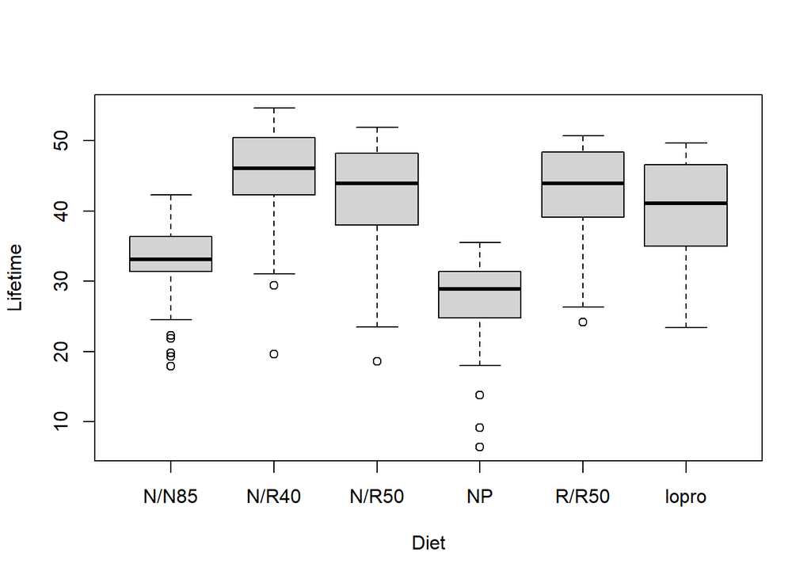

```r
## boxplot per Diet
boxplot(Lifetime ~ Diet, data = case0501)
```

```r
#comparison between all possible pairs of treatments, a total of K(K-1)/2, can be done using function pairwise.t.test (it uses a pooled standard deviation estimate from all groups).

## Without correction (but pooled sd estimate)
#pairwise.t.test(dat$Lifetime, dat$Diet, p.adjust.method = "none")
# Bonferoni adjustment
#pairwise.t.test(dat$Lifetime, dat$Diet, p.adjust.method = "bonf")
```